# TD d’évaluation de performances

Abdelaziz FOUNAS

3 Mars 2016

On souhaite évaluer l’opportunité de remplacer l’implémentation du quicksort de la libc par une version parallèle afin que toutes les applications puissent bénéficier automatiquement des architectures multi-coeurs. L’objectif de ce TD est de répondre à la question suivante :

- À partir de quelle taille de tableau devient-il opportun d’utiliser la version parallèle ?

Nous avons un code C exécutant trois différentes versions du quicksort (built-in, parallèle, séquentielle), un script BASH permettant de créer une séance de test notamment en répétant les essais et de changer les tailles des tableaux à trier. Enfin nous avons un script perl permettant d’extraire les données du script et de créer un CSV importable en R.

Après exécution du script et création d’un CSV grâce au perl nous obtenons le fichier resultat_1.csv. On peut alors l’importer en R et travailler dessus.

Nous l’importons tout d’abord :

```r
res1 <- read.csv(file="result_1.csv",head=TRUE,sep=",")
```

Voilà ci-dessous une brève vue du contenu du fichier resultat_1.csv :

```r
head(res1)
```

```
##   Size        Type     Time
## 1  100  Sequential 0.000009
## 2  100    Parallel 0.003740
## 3  100    Built-in 0.000012
## 4  100  Sequential 0.000009
## 5  100    Parallel 0.003500
## 6  100    Built-in 0.000023
```

Grâce à la librairie ggplot, nous pouvons avoir un visuel claire de la répartition des résultats selon la taille, le temps et le type :

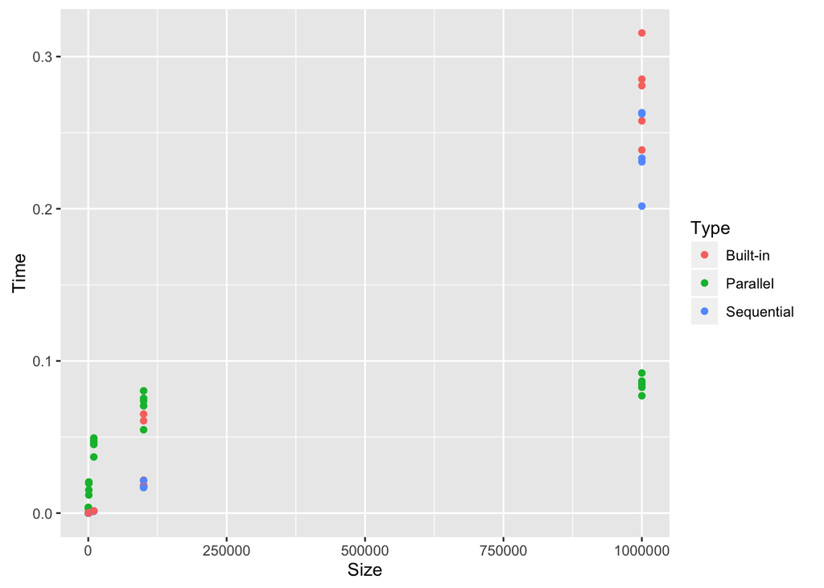

```r
p = ggplot(res1, aes(Size, Time))
p + geom_point(aes(colour = Type))
```

On peut zoomer sur les points un peu rapprochés (de 100 à 10000) :

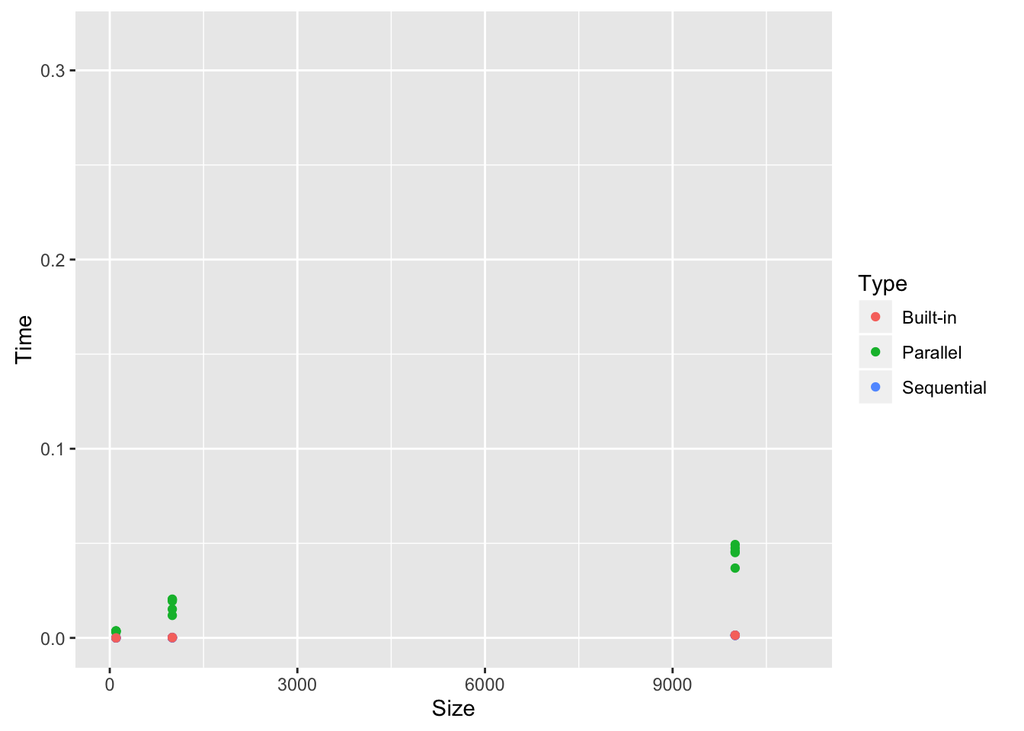

```r
p + geom_point(aes(colour = Type)) + coord_cartesian(xlim = c(0, 11000))
```

On peut aussi faire le calcul des moyennes des temps selon tous les critères :

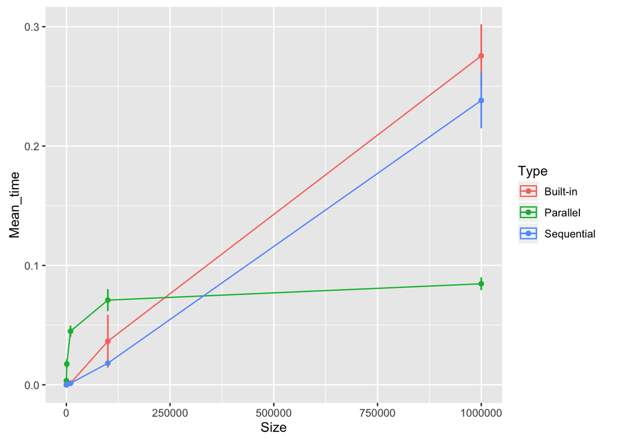

```r
res1_mine <- res1 %>% group_by(Size, Type) %>%
                  select(Time) %>%
                  summarise( num = n(),
                        Mean_time = mean(Time),
                        Time_sd = sd(Time),
                        Time_se = 2*Time_sd/sqrt(num)
                  )

ggplot(data = res1_mine,
    aes(x=Size , y=Mean_time, ymin=Mean_time-Time_se, ymax=Mean_time+Time_se, color=Type) ) +
    geom_crossbar() +
    geom_point() +
    geom_line();
```

Ça confirme l’explication plus haut, on voit que les versions built-in et séquentielle sont mieux dans les cas de petites tailles de tableaux. Mais la version Parallèle s’en sort de mieux en mieux avec le nombre d’éléments qui augmente.

On peut considérer les croisements des lignes parallèle avec built-in puis parallèle avec séquentielle, comme la version parallèle prenant le dessus sur l’autre version. Ici, la version parallèle est meilleur que la version built-in aux alentours des 250000 éléments, et est meilleure que la version séquentielle aux alentours de 330000 éléments. Tout cela en moyenne car on s’aperçoit ici aussi que les versions built-in et séquentielle sont comme instable dû aux variations qu’elles montrent contrairement encore une fois à la version parallèle qui semble être un peu plus stable à cause des résultats un peu pus agglomérés.